# Caret Package Walkthrough

##Loading the Dataset##

> First thing is first, we need to load the data. This walkthrough introduces the **mlbench** package. Mlbench is a collection of artificial and real-world machine learning benchmark problems, including several data sets from the UCI repository. Which is great. This just makes life easier when practicing machine learning.

> This walkthrough uses the **Sonar** data set. It consists of 208 data points collected on 60 predictors. The goal is to predict the two classes **M** for metal cylinder or **R** for cylinder shaped rock.

**Split the Data into Two Groups**

```r
library(caret)
library(mlbench)
data(Sonar)

set.seed(107)
inTrain <- createDataPartition(
  y = Sonar$Class,
  ## the outcome data are needed
  p = .75,
  ## the percentage of data in the training set
  list = FALSE
)
## The format of the results

## The output is a set of integers fro the rows of Sonar
## that belong in the training set.
str(inTrain)
```

```
 int [1:157, 1] 1 2 3 4 5 7 10 11 12 13 ...
 - attr(*, "dimnames")=List of 2
  ..$ : NULL
  ..$ : chr "Resample1"
```

```
#> int [1:157, 1] 1 2 3 4 5 7
#> - attr(*, "dimnames")=list of 2
#> ..$ : NULL
#> ..$ : chr "Resample1"
```

> **createDataPartition** does a stratified random split of the data.

```r
training <- Sonar[ inTrain, ]
testing  <- Sonar[-inTrain, ]

nrow(training)
```

```
[1] 157
```

```
#> [1] 157
```

```r
nrow(testing)
```

```
[1] 51
```

```
#> [1] 51
```

> Next a partial least squares discriminant analysis (PLSDA) model will be tudned over the number of PLS components that should be retained.

```r
plsFit <- train( Class ~., data = training, method = "pls",
                 ## Center and scale the predictors for the training
                 ## set and all future samples.
                 preProc = c("center", "scale")
                 )
```

> At this point the model can be customized. The walkthrough recommends expanding the PLS models, changing the type of resample from bootstrap to three repeats of 10-fold cross-validation and changing the methods for measuring performance. Normally the root mean square error and R^2 are computed, but it will need to change to estimate the area under the ROC curve.

> tuneLength=15 is used to evaluate all integers between 1 and 15.

```r
plsFit <- train(Class ~., data = training, method = "pls", preProc = c("center", "scale"),
                ## added:
                tuneLength = 15
                )
```

> Next, the resampling method needs to be changed. **trainControl** is used to do this. **Boot** is the default and needs to be changed to **repeatedcv**. For repeated cross validation.

```r
ctrl <- trainControl(method = "repeatedcv", repeats = 3)

plsFit <- train(Class ~., data = training, method = "pls", preProc = c("center", "scale"),
                tuneLength = 15,
                ## added:
                trControl = ctrl
                )
```

> Now a different method of measuring the performance is used.

```r
ctrl <- trainControl(
  method = "repeatedcv",
  repeats = 3,
  classProbs = TRUE,
  summaryFunction = twoClassSummary
)

set.seed(123)
plsFit <- train(Class~., data = training, method = "pls", preProc = c("center", "scale"),
                tuneLength = 15, trControl = ctrl, metric = "ROC"
                )
plsFit
```

```
Partial Least Squares

157 samples
 60 predictor
  2 classes: 'M', 'R'

Pre-processing: centered (60), scaled (60)
Resampling: Cross-Validated (10 fold, repeated 3 times)
Summary of sample sizes: 141, 141, 142, 142, 141, 142, ...
Resampling results across tuning parameters:

  ncomp  ROC        Sens       Spec
   1     0.8052910  0.7259259  0.6904762
   2     0.8479084  0.7495370  0.8005952
   3     0.8488426  0.7638889  0.7476190
   4     0.8355241  0.7652778  0.7357143
   5     0.8124173  0.7481481  0.7547619
   6     0.7887566  0.7236111  0.6988095
   7     0.7938161  0.7439815  0.6892857
   8     0.8012235  0.7393519  0.6982143
   9     0.7932126  0.7578704  0.6767857
  10     0.7895916  0.7412037  0.6904762
  11     0.7868386  0.7416667  0.7101190
  12     0.7773479  0.7365741  0.7148810
  13     0.7715608  0.7375000  0.7000000
  14     0.7678902  0.7175926  0.6904762
  15     0.7679729  0.7148148  0.6898810

ROC was used to select the optimal model using the largest value.
The final value used for the model was ncomp = 3.
```

> Displaying the result of the training in a **ggplot** can show the relationship to the performance of cross-validation and the number of PLS components.

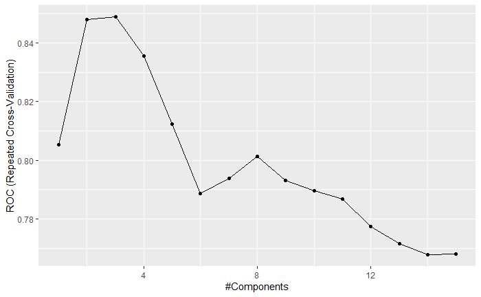

```r
ggplot(plsFit)
```

> Testing the training data comes next. The data that was partitioned from the original batch and labeled testing will be used to see if this model can predict new samples.

```r
plsClasses <- predict(plsFit, newdata = testing)
str(plsClasses)
```

```
 Factor w/ 2 levels "M","R": 2 1 1 1 2 2 1 2 2 2 ...
```

[output not shown]

```r
plsProbs <- predict(plsFit, newdata = testing, type = "prob")
head(plsProbs)
```

|  | M | R |
| --- | --- | --- |
| 6 | 0.2878477 | 0.7121523 |
| 8 | 0.6484796 | 0.3515204 |
| 9 | 0.6590434 | 0.3409566 |
| 15 | 0.5285970 | 0.4714030 |
| 26 | 0.4299690 | 0.5700310 |
| 27 | 0.4916393 | 0.5083607 |

> The confusion matrix can break down the statistics for the model fit.

```r
confusionMatrix(data = plsClasses, testing$Class)
```

```
Confusion Matrix and Statistics

          Reference
Prediction  M  R
         M 21  7
         R  6 17

               Accuracy : 0.7451
                 95% CI : (0.6037, 0.8567)
    No Information Rate : 0.5294
    P-Value [Acc > NIR] : 0.001311

                  Kappa : 0.4872

 Mcnemar's Test P-Value : 1.000000

            Sensitivity : 0.7778
            Specificity : 0.7083
         Pos Pred Value : 0.7500
         Neg Pred Value : 0.7391
             Prevalence : 0.5294
         Detection Rate : 0.4118
   Detection Prevalence : 0.5490
      Balanced Accuracy : 0.7431

       'Positive' Class : M
```

> Minor changes can be made to the **train** function to invoke new models. Below will utilize the regularized discriminant model.

```r
## To illustrate, a custom grid is used
rdaGrid = data.frame(gamma = (0:4)/4, lambda = 3/4)
set.seed(123)
rdaFit <- train(Class~., data = training, method = "rda", tuneGrid = rdaGrid,
                trControl = ctrl, metric = "ROC"
                )
```

[output not shown]

```r
1
```

[output not shown]

```r
rdaFit
```

```
Regularized Discriminant Analysis

157 samples
 60 predictor
  2 classes: 'M', 'R'

No pre-processing
Resampling: Cross-Validated (10 fold, repeated 3 times)
Summary of sample sizes: 141, 141, 142, 142, 141, 142, ...
Resampling results across tuning parameters:

  gamma  ROC        Sens       Spec
  0.00   0.7775876  0.7231481  0.6815476
  0.25   0.8865989  0.8643519  0.7863095
  0.50   0.8764964  0.8513889  0.7303571
  0.75   0.8633185  0.8300926  0.7095238
  1.00   0.7338872  0.6800926  0.6357143

Tuning parameter 'lambda' was held constant at a value of 0.75
ROC was used to select the optimal model using the largest value.
The final values used for the model were gamma = 0.25 and lambda = 0.75.
```

```r
rdaClasses <- predict(rdaFit, newdata = testing)
confusionMatrix(rdaClasses, testing$Class)
```

```
Confusion Matrix and Statistics

          Reference
Prediction  M  R
         M 25  5
         R  2 19

               Accuracy : 0.8627
                 95% CI : (0.7374, 0.943)
    No Information Rate : 0.5294
    P-Value [Acc > NIR] : 5.008e-07

                  Kappa : 0.7226

 Mcnemar's Test P-Value : 0.4497

            Sensitivity : 0.9259
            Specificity : 0.7917
         Pos Pred Value : 0.8333
         Neg Pred Value : 0.9048
             Prevalence : 0.5294
         Detection Rate : 0.4902
   Detection Prevalence : 0.5882
      Balanced Accuracy : 0.8588

       'Positive' Class : M
```

> The two models can be compared using the **resamples** function.

```r
resamps <- resamples(list(pls = plsFit, rda = rdaFit))
summary(resamps)
```

```
Call:
summary.resamples(object = resamps)

Models: pls, rda
Number of resamples: 30

ROC
         Min.   1st Qu.    Median      Mean   3rd Qu.     Max. NA's
pls 0.6785714 0.7872024 0.8234127 0.8488426 0.9375000 0.984127    0
rda 0.7500000 0.8470982 0.8888889 0.8865989 0.9404762 1.000000    0

Sens
         Min.   1st Qu. Median      Mean 3rd Qu. Max. NA's
pls 0.5555556 0.6250000  0.750 0.7638889   0.875    1    0
rda 0.6250000 0.7569444  0.875 0.8643519   1.000    1    0

Spec
         Min.   1st Qu.    Median      Mean   3rd Qu. Max. NA's
pls 0.4285714 0.7142857 0.7142857 0.7476190 0.8571429    1    0
rda 0.5000000 0.7142857 0.7500000 0.7863095 0.8750000    1    0
```